```python
import numpy as np
import pandas as pd
from scipy.stats import kruskal, kstest, linregress
from matplotlib import pyplot as plt
```

# Problem 1

## 0. Import data

```python
clim = pd.read_csv('camels_clim.csv', sep=';')
geol = pd.read_csv('camels_geol.csv', sep=';')
hydro = pd.read_csv('camels_hydro.csv', sep=';')
name = pd.read_csv('camels_name.csv', sep=';')
soil = pd.read_csv('camels_soil.csv', sep=';')
topo = pd.read_csv('camels_topo.csv', sep=';')
vege = pd.read_csv('camels_vege.csv', sep=';')

camels = pd.merge(name, clim, on='gauge_id')
camels = pd.merge(camels, geol, on='gauge_id')
camels = pd.merge(camels, hydro, on='gauge_id')
camels = pd.merge(camels, soil, on='gauge_id')
camels = pd.merge(camels, topo, on='gauge_id')
camels = pd.merge(camels, vege, on='gauge_id')

camels = camels.dropna()
```

## i. Boxplot and eCDF of regional q_mean

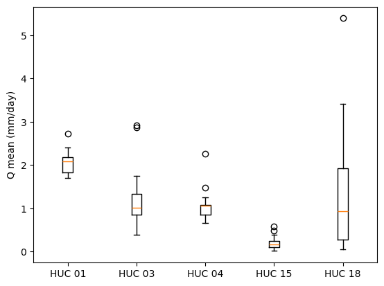

```python
hucs = np.array([1, 3, 4, 15, 18])
labeler = lambda x: f'HUC {x:02d}'
labels = np.array([labeler(h) for h in hucs])

fig, ax = plt.subplots()

for n in range(len(hucs)):
    h = hucs[n]
    ax.boxplot(camels.loc[camels['huc_02'] == h, 'q_mean'], positions=[n])

ax.set_xticklabels(labels)
ax.set_ylabel('Q mean (mm/day)')
```

```
Median Q_mean for HUC 01 = 2.0776 mm/day
Median Q_mean for HUC 03 = 1.0166 mm/day
Median Q_mean for HUC 04 = 1.0563 mm/day
Median Q_mean for HUC 15 = 0.1592 mm/day
Median Q_mean for HUC 18 = 0.9392 mm/day
```

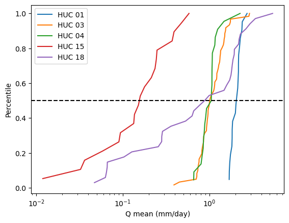

```python
medians = np.zeros(len(hucs))

fig, ax = plt.subplots()

for n in range(len(hucs)):
    h = hucs[n]
    Q = camels.loc[camels['huc_02'] == h, 'q_mean']
    Q = Q.sort_values(ascending=True)
    percentiles = Q.rank(pct=True)
    median = np.median(Q)
    print(f'Median Q_mean for {labels[n]} = {median:.4f} mm/day')
    ax.plot(Q, percentiles, label=labels[n])

ax.axhline(0.5, c='black', linestyle='--')
ax.legend()
ax.set_xscale('log')
ax.set_xlabel('Q mean (mm/day)')
ax.set_ylabel('Percentile')
```

## ii. Is any group significantly different?

H_0: No HUC2 region has a significantly different distribution of Q_mean from the others.  
H_A: At least one HUC2 region has a distribution of Q_mean that differs significantly from the others.

Test using Kruskal Wallis H test.

```python
huc_Qlist = [camels.loc[camels['huc_02'] == h, 'q_mean'].values for h in hucs]

test_statistic, p = kruskal(huc_Qlist[0], huc_Qlist[1], huc_Qlist[2], huc_Qlist[3], huc_Qlist[4])

print(f'p = {p}')
if p < 0.05:
    print('Reject H_0; this test suggests that at least one region has a distribution of Q_mean that differs from the others.')
else:
    print('Fail to reject H_0; the test does not show significant differences in regional distributions of Q_mean')
```

```
p = 4.9321610663879954e-14
Reject H_0; this test suggests that at least one region has a distribution of Q_mean that differs from the others.
```

## iii. Which pairings are significantly different?

```python
for n in range(len(hucs)):
    for m in range(len(hucs)):
        if n <= m:
            break

        h0 = hucs[n]
        h1 = hucs[m]

        Q0 = huc_Qlist[n]
        Q1 = huc_Qlist[m]

        test_statistic, p = kruskal(Q0, Q1)

        if p < 0.05:
            print(f'HUC {h0} and HUC {h1} differ significantly (p = {p})')

        else:
            print(f'HUC {h0} and HUC {h1} do not differ significantly (p = {p})')
```

```
HUC 3 and HUC 1 differ significantly (p = 3.53446771244033e-10)
HUC 4 and HUC 1 differ significantly (p = 1.9988340800412732e-07)
HUC 4 and HUC 3 do not differ significantly (p = 0.3584838011817658)
HUC 15 and HUC 1 differ significantly (p = 6.544376142124379e-08)
HUC 15 and HUC 3 differ significantly (p = 8.289105009051541e-11)
HUC 15 and HUC 4 differ significantly (p = 4.650803023847322e-08)
HUC 18 and HUC 1 differ significantly (p = 0.0014345334960579972)
HUC 18 and HUC 3 do not differ significantly (p = 0.7679875433234646)
HUC 18 and HUC 4 do not differ significantly (p = 0.8273550776438338)
HUC 18 and HUC 15 differ significantly (p = 0.0002077242768261654)
```

## iv. What should alpha_pair be to ensure that alpha_family is 0.05?

Where k is the number of groups among which comparisons are made, the number of pair comparisons c is given by:  
c = k (k - 1) / 2

k = 5  
c = 10

alpha_family = 1 - (1 - alpha_pair) ^ c  
alpha_pair = 0.00512

# Problem 2

## i. KS test for normality:

```python
for n in range(len(hucs)):
    Q = huc_Qlist[n]
    h = hucs[n]
    statistic, p = kstest(Q, 'norm')

    if p < 0.05:
        print(f'Reject H_0; HUC {h} follows a normal distribution (p = {p})')
    else:
        print(f'Fail to reject H_0; HUC {h} is not shown to follow a normal distribution (p = {p})')
```

```
Reject H_0; HUC 1 follows a normal distribution (p = 9.519502592637684e-29)
Reject H_0; HUC 3 follows a normal distribution (p = 2.259946615425861e-33)
Reject H_0; HUC 4 follows a normal distribution (p = 4.1030071663560305e-13)
Reject H_0; HUC 15 follows a normal distribution (p = 5.239316031042037e-05)
Reject H_0; HUC 18 follows a normal distribution (p = 4.930813402722242e-09)
```

## ii. Calculate Cohen's d to identify effect size in differences between groups.

```python
d1 = 0
d3 = 0
d4 = 0
d15 = 0
d18 = 0

def cohen_d(g0, g1):
    mean0 = np.mean(g0)
    mean1 = np.mean(g1)

    stdev = np.std(
        np.concatenate([g0, g1])
    )

    return (mean0 - mean1) / stdev


for n in range(len(hucs)):
    for m in range(len(hucs)):
        if n <= m:
            break

        h0 = hucs[n]
        h1 = hucs[m]

        Q0 = huc_Qlist[n]
        Q1 = huc_Qlist[m]

        d = cohen_d(Q0, Q1)

        if h0 == 1 or h1 == 1:
            d1 = d1 + np.abs(d)
        if h0 == 3 or h1 == 3:
            d3 = d3 + np.abs(d)
        if h0 == 4 or h1 == 4:
            d4 = d4 + np.abs(d)
        if h0 == 15 or h1 == 15:
            d15 = d15 + np.abs(d)
        if h0 == 18 or h1 == 18:
            d18 = d18 + np.abs(d)

        print(f'HUC {h0} and HUC {h1} differ with Cohen\'s d = {d}.')
```

```
HUC 3 and HUC 1 differ with Cohen's d = -1.607292416043161.
HUC 4 and HUC 1 differ with Cohen's d = -1.7234356234206856.
HUC 4 and HUC 3 differ with Cohen's d = -0.22238089645984327.
HUC 15 and HUC 1 differ with Cohen's d = -1.9488625985727457.
HUC 15 and HUC 3 differ with Cohen's d = -1.672080251775142.
HUC 15 and HUC 4 differ with Cohen's d = -1.7081609066202208.
HUC 18 and HUC 1 differ with Cohen's d = -0.7590752613047586.
HUC 18 and HUC 3 differ with Cohen's d = 0.17429709834639484.
HUC 18 and HUC 4 differ with Cohen's d = 0.24274704894690602.
HUC 18 and HUC 15 differ with Cohen's d = 0.9910268324751687.
```

## iii. Infer practical significance of differences between groups.

Summing the absolute value of Cohen's d per region reveals that HUCs 15 and 1 differ most from the other regions. It makes sense that HUC 15 in the southern Basin and Range would differ from the others since it is by far the most arid. It also makes sense that HUC 1 in New England differs from the others as precipitation is high and relatively evenly distributed through the year. HUC 18 (California) shows the smallest sum Cohen's d, which could be interpreted to mean the least different from the others. This may be due to the fact that flows in HUC 18 are the most variable (see boxplot from 1. i.), and Cohen's d is a function of 1 / standard deviation.

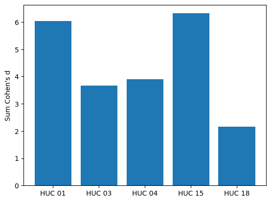

```python
fig, ax = plt.subplots()
ax.bar([0, 1, 2, 3, 4], [d1, d3, d4, d15, d18])
ax.set_xticks([0, 1, 2, 3, 4])
ax.set_xticklabels(labels)
ax.set_ylabel('Sum Cohen\'s d')
```

# Problem 3

## i. Linear correlation between q_mean and p_mean

```
HUC 1 Pearson r = 0.6199604308610039
HUC 3 Pearson r = 0.801151558729041
HUC 4 Pearson r = 0.7907315189563194
HUC 15 Pearson r = 0.662728262054754
HUC 18 Pearson r = 0.9075531171551149
```

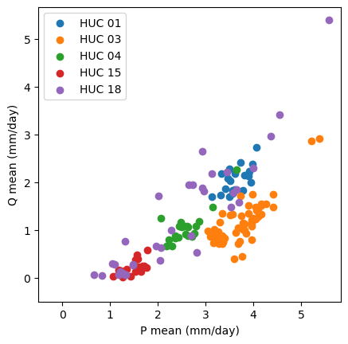

```python
plist = []
rlist = []

fig, ax = plt.subplots()

cs = ['tab:blue', 'tab:orange', 'tab:green', 'tab:red', 'tab:purple']

for n in range(len(hucs)):
    h = hucs[n]
    Q = camels.loc[camels['huc_02'] == h, 'q_mean']
    P = camels.loc[camels['huc_02'] == h, 'p_mean']
    ax.scatter(P, Q, label=labels[n])

    lr = linregress(P, Q)
    r = lr[2]
    p = lr[3]

    plist.append(p)

    print(f'HUC {h} Pearson r = {r}')

ax.legend()
ax.set_xlabel('P mean (mm/day)')
ax.set_ylabel('Q mean (mm/day)')
ax.set_xlim(-0.5)
ax.set_ylim(-0.5)
ax.set_aspect('equal')
```

## ii. Are any linear correlations statistically significant?

```python
for n in range(len(hucs)):
    h = hucs[n]
    p = plist[n]

    print(f'HUC {h} correlation between Q and P p = {p}')
```

```
HUC 1 correlation between Q and P p = 0.0027191053036771467
HUC 3 correlation between Q and P p = 8.957928613004124e-15
HUC 4 correlation between Q and P p = 1.1861395517084918e-05
HUC 15 correlation between Q and P p = 0.001986539137766657
HUC 18 correlation between Q and P p = 1.3406256676936626e-13
```

All are statistically significant.